# MicF Regulation

Alex Dang

5/8/2022

# Introduction

For this project, we will be looking at a project completed in my Bacterial Genetics Lab for the Spring 2022 semester, and my further analysis on the class project data.

## Background

In *Escheria coli*, the MicF RNA gene controls the expression of the outer membrane porin gene *ompF*.

There are 10 genes used to test whether or not MicF regulate translation of them. Results are made upon making comparative observations based on fluorescence absorbency (FL/OD) between the gene-gfp control and gene-gfp-MicF. Three possible results are activation, repression, and inconclusive. If there is a significant greater FL/OD in the gene-gfp-MicF, MicF activates the gene. If there is a significant lower FL/OD in the gene-gfp-MicF, MicF represses the gene.

- *wza*: produces the protein that is responsible for the transport of capsular polysaccharide from periplasmic space to surface, and the participation in the formaiton of bacterial capsules
- *sbcB*: produces the protein that degrades ssDNAs, and releases deoxyribose-phosphate moeities after the cleavage of DNA at an AP site
- *ysaB*: produces the non-essential lipoprotein. Function not well-studied
- *smrB*: produces the protein that cleaves mRNAs upstream of paused ribosomes
- *seqA*: produces the protein that modulates the replication initiation at *E. coli* oriC
- *hypB*: produces the aporepressor protein that is involved in teh maturation of NiFe, and transfer of nickle from the HypB GTPase domain to HypA in the presence of GDP
- *serA*: produces the protein that catalyzes the reversible oxidation of 3-phospho-D-glycerate to 3-phosphooxypyruvate and of 2-hydroxyglutarate to 2-oxoglutarate
- *rsmD*: produces the protein that methylates the guanine in position 966 of 16S rRNA in the assembled 30S particle
- *lrp*: produces the protein that mediates the global reponse to leucine
- *ybaY*: produces the protein involved in lipoprotein biosynthesis and glycoprotein biosynthesis

Overall results of MicF regulation was not well presented by students in the class in my opinion. Therefore, I am performing t-tests to get better results confirmed with the calculated p-values.

# Load libraries

```r
library(tidyverse)
library(here)
library(rstatix)
library(ggpubr)
library(kableExtra)
library(patchwork)
library(flair)
library(tvthemes)
library(sysfonts)
library(showtextdb)
library(showtext)
```

## Add fonts

```r
font_add_google("Zen Loop", "zen")
```

# Load data

```r
All_Genes <- read_csv(here("MicF_reg", "data", "all_genes_FL_OD.csv"))
view(All_Genes)
```

# Data analysis

To obtain each gene p-value and average FL/0D.

```r
All_Genes %>%
  drop_na()
```

```
## # A tibble: 5 x 20
##   wza         wza_FL_OD sbcB  sbcB_FL_OD ysaB  ysaB_FL_OD smrB  smrB_FL_OD seqA
##   <chr>           <dbl> <chr>      <dbl> <chr>      <dbl> <chr>      <dbl> <chr>
## 1 wza_gfp_ct~      1210 sbcB~      12936 ysaB~       1051 smrB~       1968 seqA~
## 2 wza_gfp_ct~      1650 sbcB~      15619 ysaB~        624 smrB~       1791 seqA~
## 3 wza_gfp_ct~      1800 sbcB~      15680 ysaB~       1622 smrB~       2644 seqA~
## 4 wza_gfp_Mi~       423 sbcB~       7651 ysaB~       2243 smrB~       3802 seqA~
## 5 wza_gfp_Mi~      1985 sbcB~      11564 ysaB~       2644 smrB~       3871 seqA~
## # ... with 11 more variables: seqA_FL_OD <dbl>, hypB <chr>, hypB_FL_OD <dbl>,
## #   serA <chr>, serA_FL_OD <dbl>, rsmD <chr>, rsmD_FL_OD <dbl>, lrp <chr>,
## #   lrp_FL_OD <dbl>, ybaY <chr>, ybaY_FL_OD <dbl>
```

```r
wza_p <- All_Genes %>%
  t_test(wza_FL_OD ~ wza) %>%
  write_csv(here("MicF_reg", "data", "p_values", "wza_p.csv"))

sbcB_p <- All_Genes %>%
  t_test(sbcB_FL_OD ~ sbcB) %>%
  write_csv(here("MicF_reg", "data", "p_values", "sbcB_p.csv"))

ysaB_p <- All_Genes %>%
  t_test(ysaB_FL_OD ~ ysaB) %>%
  write_csv(here("MicF_reg", "data", "p_values", "ysaB_p.csv"))

smrB_p <- All_Genes %>%
  t_test(smrB_FL_OD ~ smrB) %>%
  write_csv(here("MicF_reg", "data", "p_values", "smrB_p.csv"))

seqA_p <- All_Genes %>%
  t_test(seqA_FL_OD ~ seqA) %>%
  write_csv(here("MicF_reg", "data", "p_values", "seqA_p.csv"))

hypB_p <- All_Genes %>%
  t_test(hypB_FL_OD ~ hypB) %>%
  write_csv(here("MicF_reg", "data", "p_values", "hypB_p.csv"))

serA_p <- All_Genes %>%
  t_test(serA_FL_OD ~ serA) %>%
  write_csv(here("MicF_reg", "data", "p_values", "serA_p.csv"))

rsmD_p <- All_Genes %>%
  t_test(rsmD_FL_OD ~ rsmD) %>%
  write_csv(here("MicF_reg", "data", "p_values", "rsmD_p.csv"))

lrp_p <- All_Genes %>%
  t_test(lrp_FL_OD ~ lrp) %>%
  write_csv(here("MicF_reg", "data", "p_values", "lrp_p.csv"))

ybaY_p <- All_Genes %>%
  t_test(ybaY_FL_OD ~ ybaY) %>%
  write_csv(here("MicF_reg", "data", "p_values", "ybaY_p.csv"))
```

# Table

Now, to make a table that display the p-values to the corresponding gene.

```r
p_Path <- here("MicF_reg", "data", "p_values")

p_files <- dir(path = p_Path, pattern = ".csv", full.names = TRUE)

p_data1 <-p_files %>%
  set_names() %>%
  map_df(read_csv, .id = "filename") %>%
  group_by(filename) %>%
  mutate(Control = group1, MicF = group2) %>%
  summarise(Control, MicF, p) %>%
  kbl() %>%
  kable_material() %>%
  kable_material_dark(c("striped", "hover", "condensed", "responsive"),
                full_width = FALSE, fixed_thead = T, position = "center",
                font_size = 12) %>%
  row_spec(0, bold = T, color = "white", background = "gray")
p_data2 <- p_data1 %>%
  row_spec(1:10, color = "gray") %>%
  as_image(here("MicF_reg", "output", "all_gene_p_table.png"),
           width = 5, height = 8)
p_data1
```

| filename | Control | MicF | p |
| --- | --- | --- | --- |
| D:/CSUN/BIO551 CMPTR MODEL/Dang_IFP/MicF_reg/data/p_values/hypB_p.csv | hypB_gfp_ctrl | hypB_gfp_MicF | 0.5470 |
| D:/CSUN/BIO551 CMPTR MODEL/Dang_IFP/MicF_reg/data/p_values/lrp_p.csv | lrp_gfp_ctrl | lrp_gfp_MicF | 0.3700 |
| D:/CSUN/BIO551 CMPTR MODEL/Dang_IFP/MicF_reg/data/p_values/rsmD_p.csv | rsmD_gfp_ctrl | rsmD_gfp_MicF | 0.2410 |
| D:/CSUN/BIO551 CMPTR MODEL/Dang_IFP/MicF_reg/data/p_values/sbcB_p.csv | sbcB_gfp_ctrl | sbcB_gfp_MicF | 0.0696 |
| D:/CSUN/BIO551 CMPTR MODEL/Dang_IFP/MicF_reg/data/p_values/seqA_p.csv | seqA_gfp_ctrl | seqA_gfp_MicF | 0.8840 |
| D:/CSUN/BIO551 CMPTR MODEL/Dang_IFP/MicF_reg/data/p_values/serA_p.csv | serA_gfp_ctrl | serA_gfp_MicF | 0.4890 |
| D:/CSUN/BIO551 CMPTR MODEL/Dang_IFP/MicF_reg/data/p_values/smrB_p.csv | smrB_gfp_ctrl | smrB_gfp_MicF | 0.0210 |
| D:/CSUN/BIO551 CMPTR MODEL/Dang_IFP/MicF_reg/data/p_values/wza_p.csv | wza_gfp_ctrl | wza_gfp_MicF | 0.5050 |
| D:/CSUN/BIO551 CMPTR MODEL/Dang_IFP/MicF_reg/data/p_values/ybaY_p.csv | ybaY_gfp_ctrl | ybaY_gfp_MicF | 0.1550 |
| D:/CSUN/BIO551 CMPTR MODEL/Dang_IFP/MicF_reg/data/p_values/ysaB_p.csv | ysaB_gfp_ctrl | ysaB_gfp_MicF | 0.0308 |

## Adding Flair

```r
decorate('p_data <-p_files %>%
  set_names() %>%
  map_df(read_csv, .id = "filename") %>%
  group_by(filename) %>%
  mutate(Control = group1, MicF = group2) %>%
  summarise(Control, MicF, p) %>%
  kbl() %>%
  kable_material() %>%
  kable_styling(bootstrap_options = c("striped", "hover", "condensed", "responsive"),
                full_width = FALSE, fixed_thead = T, position = "center",
                font_size = 12)') %>%
  flair_funs(color = "Coral", underline = TRUE) %>%
  knit_print.with_flair()
```

```r
p_data <-p_files %>%
  set_names() %>%
  map_df(read_csv, .id = "filename") %>%
  group_by(filename) %>%
  mutate(Control = group1, MicF = group2) %>%
  summarise(Control, MicF, p) %>%
  kbl() %>%
  kable_material() %>%
  kable_styling(bootstrap_options = c("striped", "hover", "condensed", "responsive"),
                full_width = FALSE, fixed_thead = T, position = "center",
                font_size = 12)
```

# Function

Make a function for skeleton plot coding to help speed up the process of plotting each gene results.

```r
showtext_auto()

MicF_reg_plot <- function(data = All_Genes, x, y){
  ggplot(data, aes(x = {{x}}, y = {{y}}, color = {{x}})) +
    geom_boxplot() +
    theme_hildaNight() +
    theme(plot.title = element_text(size = 42, hjust = 0.5, family = "zen"),
        axis.title = element_text(size = 26, family = "zen"),
        axis.text = element_text(size = 20, family = "zen"),
        plot.caption = element_text(size = 10)) +
    labs(title = "MicF Expression Assay",
       x = "Genes",
       y = "FL/OD",
       caption = "BIO467L Bacterial Genetics by Takahashi")
}
```

# Plots

Plots will be grouped together to the following:

- Group 1: *wza* and *sbcB*
- Group 2: *ysaB* and *smrB*
- Group 3: *seqA* and *hypB*
- Group 4: *serA* and *rsmD*
- Group 5: *lrp* and *ybaY*

```r
wza_plot <- MicF_reg_plot(x = wza, y = wza_FL_OD) +
  ylim(300, 2300) +
  stat_pvalue_manual(wza_p, label = "p", y.position = 2100)

sbcB_plot <- MicF_reg_plot(x = sbcB, y = sbcB_FL_OD) +
  ylim(6000, 19000) +
  stat_pvalue_manual(sbcB_p, label = "p", y.position = 17000)

ysaB_plot <- MicF_reg_plot(x = ysaB, y = ysaB_FL_OD) +
  ylim(500, 2800) +
  stat_pvalue_manual(ysaB_p, label = "p", y.position = 2600)

smrB_plot <- MicF_reg_plot(x = smrB, y = smrB_FL_OD) +
  ylim(1500, 4400) +
  stat_pvalue_manual(smrB_p, label = "p", y.position = 4200)

seqA_plot <- MicF_reg_plot(x = seqA, y = seqA_FL_OD) +
  ylim(1500, 4000) +
  stat_pvalue_manual(seqA_p, label = "p", y.position = 3800)

hypB_plot <- MicF_reg_plot(x = hypB, y = hypB_FL_OD) +
  ylim(4500, 12000) +
  stat_pvalue_manual(hypB_p, label = "p", y.position = 11500)

serA_plot <- MicF_reg_plot(x = serA, y = serA_FL_OD) +
  ylim(1500, 4200) +
  stat_pvalue_manual(serA_p, label = "p", y.position = 4000)

rsmD_plot <- MicF_reg_plot(x = rsmD, y = rsmD_FL_OD) +
  ylim(2000, 3400) +
  stat_pvalue_manual(rsmD_p, label = "p", y.position = 3200)

lrp_plot <- MicF_reg_plot(x = lrp, y = lrp_FL_OD) +
  ylim(1500, 6000) +
  stat_pvalue_manual(lrp_p, label = "p", y.position = 5800)

ybaY_plot <- MicF_reg_plot(x = ybaY, y = ybaY_FL_OD)+
  ylim(5500, 10000) +
  stat_pvalue_manual(ybaY_p, label = "p", y.position = 9800)
```

## Group 1

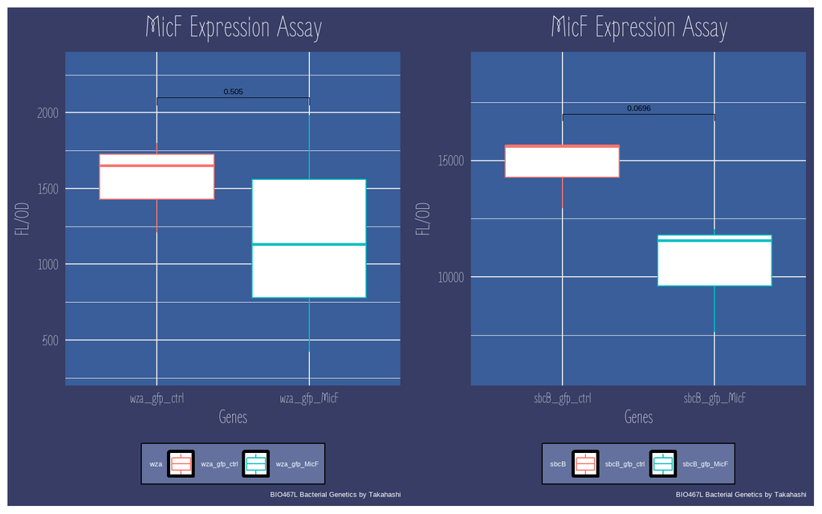

```r
wza_plot + sbcB_plot
```

## Group 2

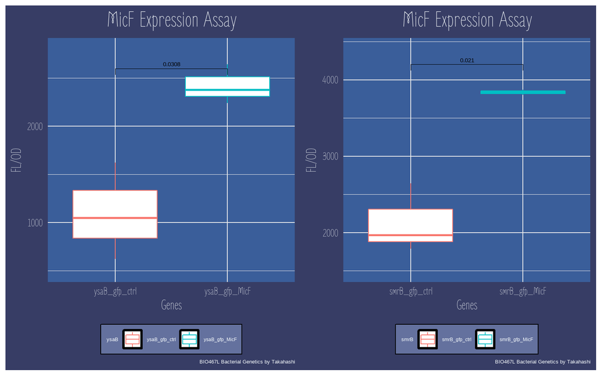

```r
ysaB_plot + smrB_plot
```

## Group 3

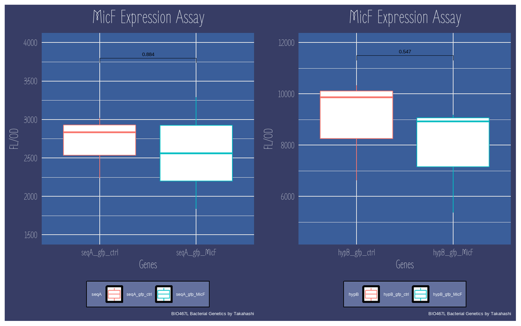

```r
seqA_plot + hypB_plot
```

## Group 4

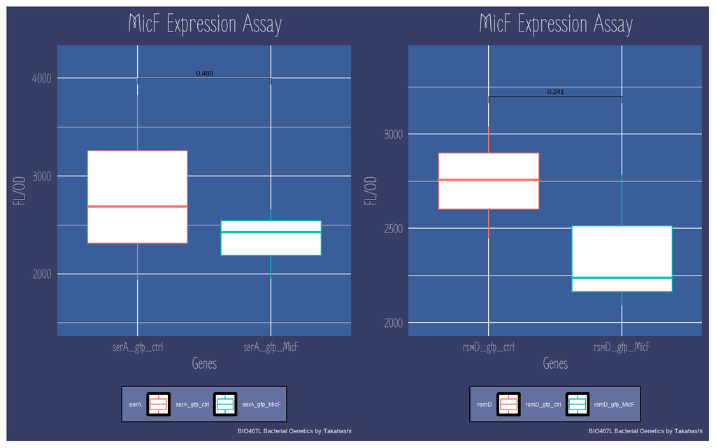

```r
serA_plot + rsmD_plot
```

## Group 5

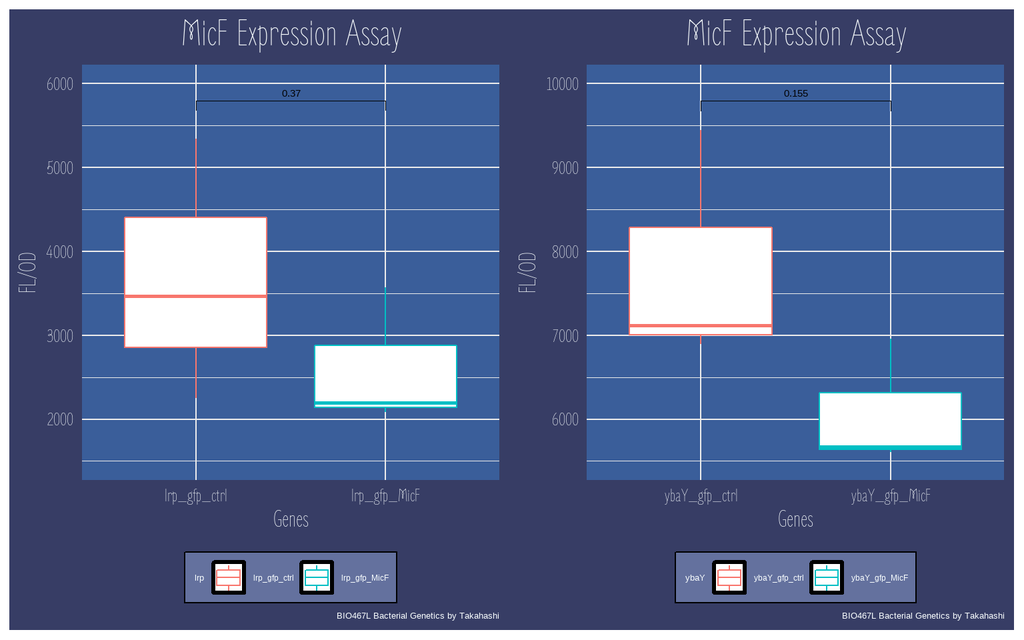

```r
lrp_plot + ybaY_plot
```

# MicF regulation result conclusions

The overall average p-value is 0.33. Examining the results based on a typical 95% confidence level (p<0.05) would conclude most of the genes as “Inconclusive”. Therefore, I have to conclude the results based on the average p-value. I decided to examine the results based on 75% confidence level (p<0.25).

- *wza*: Inconclusive
- *sbcB*: Repression
- *ysaB*: Activation
- *smrB*: Activation
- *seqA*: Inconclusive
- *hypB*: Inconclusive
- *serA*: Inconclusive
- *rsmD*: Repression
- *lrp*: Inconclusive
- *ybaY*: Repression

# Reference:

1. Delihas N, Forst S. 2001. MicF: an antisense RNA gene involved in response of Escherichia coli to global stress factors. J Mol Biol 313:1-12.
2. Lesnyak DV, Osipiuk J, Sergiev PV, Bogdanov AA, Edwards A, Joachimiak A, Dontsova OA. 2007. Methyltransferase that modifies guanine 966 of the 16S rRNA: functional identication and tertiary structure structure. J Biol Chem 282:5880-7.
3. Niu, Tianshui, et al. 2019. *Wza* gene knockout decreases *Acinetobacter baumannii* virulence and affects Wzy-dependent capsular polysaccharide synthesis. Virulence. 2020; 11(1): 1–13.
4. Saito, Kazuki, et al. 2021. Ribosome collision in bacteria promote ribosome rescue by triggering mRNA cleavage by SmrB. bioRxiv 2021.08.16.456513.
5. Slater, S, et al. 1995. E. coli SeqA protein binds oriC in two different methyl-modulated reactions appropriate to its role in DNA replication initiation and origin sequestration. Cell. 1995 Sep 22;82(6):927-36.
6. UniProtKB-P04995 (EX1_ECOLI). UniProt.
7. UniProtKB-P0AAN3 (HYPB_ECOLI). UniProt.
8. uniProtKB-P0ACJ0 (LRP_ECOLI). UniProt.
9. ybaY. STRING CONSORTIUM. 2022.
10. Zhao G, Wrinkler ME. 1996. A novel alpha-ketoglutarate reductase activity of the serA-encoded 3-phosphoglycerate dehydrogenase of Escherichia coli K-12 and its possible implications for human 2-hydroxyglutaric aciduria. J Bacteriol 178:232-9.